# Effects of Loan Characteristics on Borrower's APR

## by (Lizz Mwangi)

## Investigation Overview

The investigation here is aimed at showing how some loan features have an effect on the Borrower's APR. The focus is on Loan Original Amount, Employment Status and Prosper Rating.

## Dataset Overview

The data contains 113,937 loans with 81 variables on each loan, including loan amount, borrower rate (or interest rate), current loan status, borrower income, and many others. I used a subset of the data with a few variables in my analysis. The major alteration to the data set was merging CreditGrade and ProsperRating (Alpha) columns into one, ProsperRating, since they had similar values

## Distribution of Borrower APR

The distribution of the borrower APR's looks multimodal with several peaks. There is also a peculiar peak between 0.3 and 0.4

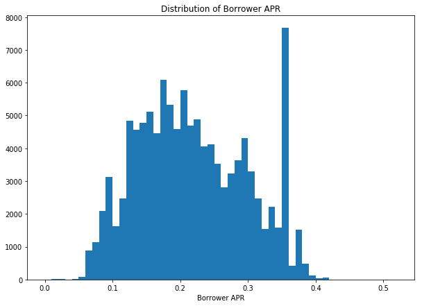

## Relationship between BorrowerAPR, LoanOriginalAmount, Prosper Rating and Employment Status.

When the borrower's prosper rating in the High Risk Category, the borrower gets very small amounts of loans lended.These smaller loans seem to have a higher APR.

The borrower APR is very high for High Risk Borrowers. Investors seem to earn more from such borrower's since their APR is high.

The Borrower APR doesn't seem to related on the employment status of the borrower.

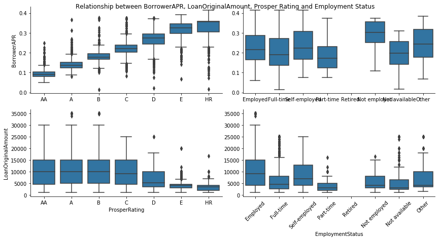

## Effect of Prosper Rating on Borrower's APR and Loan Original Amounts

Borrowers with High Risk Rating get low loan amounts but it's interesting how with this same category, the Borrower APR increases with an increase in Loan Amounts.

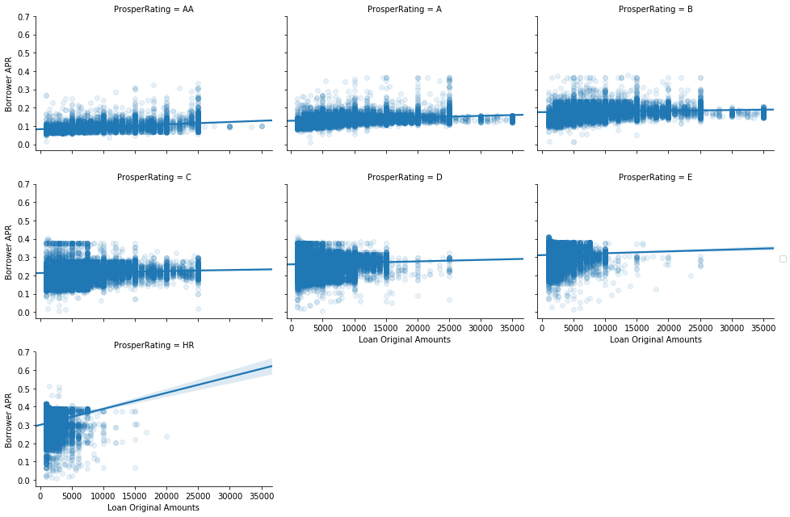

## Association between Prosper Rating, Loan Original Amount and Loan Status

[figure not shown]